# COSC-523: Project 02: Face Detection Pipeline with Haar Cascade

## Task 1b: Finding largest vessles

- Choose the vessel file: rf071808rol439_CNP.jpg and apply all the operations you applied to it in Task 1a. While applying closing you might want to increase the kernel element structure size to see better closed vessels and not have too many broken vessels. The paper used a value of 2 because it had a different objective than what we are trying to achieve here.
- Now use the connected components methodoly to find the number of connected vessels. Call the function to display the labeled image. You will see a colorful image
- Our goal now is to create a binary image that only shows us the largest vessel. In this particular image, the largest (spanning the most pixels) connected vessels are the group on the top right, green in color (look at the connected vessels image provided for reference). We need to go from this to biggest_vessel.PNG, thats what we need to create. Here are some hints on how to do this:
- The labels_im variable gives you the numpy array for the oringinal image with every pixel having the label of which component it belongs to. You can use np.unique to figure out how many unique labels there are (you can use a variation of np.unique to figure out pixel count for each label). For my code, I have 48 unique labels on the image. Also, as an example, the label 0 appears on 519172 pixels, which denotes the largest connected component in the image, the area without the vessels
- Now in order to find the largest vessel you have to find the 2nd largest group of pixels belonging to a label
- Once you have found the 2nd largest pixel value belonging to a label, find that label and use np.where to create an image where only the pixels belonging to the largest vessels are white and rest everything is black, the final output image is given for reference. Dsiplay the final image

```
Number of connected components: 48
```

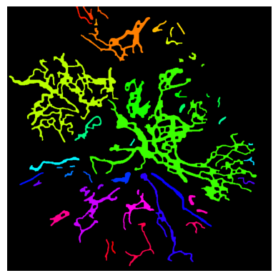

```python
vessel = cv2.imread('/content/rf071808rol439_CNP_vessel_mask.jpg')
vessel_gray = cv2.cvtColor(vessel, cv2.COLOR_BGR2GRAY)

#Convert to binary
ret, vessel_thresh = cv2.threshold(vessel_gray, 127, 255, cv2.THRESH_BINARY)

#perform dilation
kernel = np.ones((3,3),np.uint8)
vessel_dilation = cv2.dilate(vessel_thresh,kernel,iterations = 1)
#perform closing
kernel2 = np.ones((6,6),np.uint8)
vessel_closing = cv2.morphologyEx(vessel_dilation, cv2.MORPH_CLOSE, kernel2)

#connected components
num_labels, labels_im = cv2.connectedComponents(vessel_closing)
print("Number of connected components:", num_labels)

def imshow_components(labels):
    # Map component labels to hue val
    label_hue = np.uint8(179 * labels / np.max(labels))
    blank_ch = 255 * np.ones_like(label_hue)
    labeled_img = cv2.merge([label_hue, blank_ch, blank_ch])

    # cvt to BGR for display
    labeled_img = cv2.cvtColor(labeled_img, cv2.COLOR_HSV2BGR)

    # set bg label to black
    labeled_img[label_hue==0] = 0

    plt.imshow(cv2.cvtColor(labeled_img, cv2.COLOR_BGR2RGB))
    plt.axis('off')
    plt.show()

imshow_components(labels_im)
```

```python
#Get counts of pixels by label

unique_labels, counts = np.unique(labels_im, return_counts=True)
for label, count in zip(unique_labels, counts):
    print(f"Label {label}: {count} pixels")
```

```
Label 0: 516089 pixels
Label 1: 307 pixels
Label 2: 331 pixels
Label 3: 196 pixels
Label 4: 4570 pixels
Label 5: 93 pixels
Label 6: 401 pixels
Label 7: 173 pixels
Label 8: 125 pixels
Label 9: 305 pixels
Label 10: 15633 pixels
Label 11: 232 pixels
Label 12: 110 pixels
Label 13: 49 pixels
Label 14: 29505 pixels
Label 15: 3676 pixels
Label 16: 254 pixels
Label 17: 51 pixels
Label 18: 131 pixels
Label 19: 250 pixels
Label 20: 1005 pixels
Label 21: 165 pixels
Label 22: 104 pixels
Label 23: 61 pixels
Label 24: 1126 pixels
Label 25: 189 pixels
Label 26: 61 pixels
Label 27: 64 pixels
Label 28: 170 pixels
Label 29: 167 pixels
Label 30: 824 pixels
Label 31: 358 pixels
Label 32: 1712 pixels
Label 33: 2742 pixels
Label 34: 236 pixels
Label 35: 160 pixels
Label 36: 135 pixels
Label 37: 378 pixels
Label 38: 2789 pixels
Label 39: 84 pixels
Label 40: 1603 pixels
Label 41: 341 pixels
Label 42: 211 pixels
Label 43: 880 pixels
Label 44: 385 pixels
Label 45: 976 pixels
Label 46: 255 pixels
Label 47: 162 pixels
```

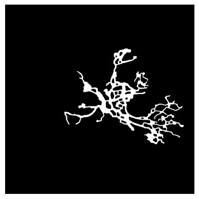

```python
#adjust function to only show the label we want
def imshow_components_specific(labels, target_label):
  binary_mask = np.where(labels == target_label, 255, 0).astype(np.uint8)
  plt.imshow(binary_mask, cmap='gray')
  plt.axis('off')
  plt.show()
imshow_components_specific(labels_im, 14)
```

## Task 2a: LICENSE PLATE DETECTION USING HAAR CASCADES

During Week 4 we implemented Haar Cascades for face detection. In this project we will use Haar Cascades for License Plate Detection. Here are the important steps:

- Download the images Car1 and Car2 on Canvas
- The article link for Task 2 shows a complete implementation of Haar Cascades for License Plate Detection
- Go through this article thoroughly and use the code provided in it to read the license plates for Car1 and Car2
- The following is code you should include at the start of your notebook:

```python
!apt-get install tesseract-ocr -y
!pip install pytesseract
!tesseract --version
! pip install Pillow
```

[output not shown]

- At the very end, you might still see a small error like "NameError: name 'pytesseract' is not defined", you should be able to fix this quickly.

```python
#upload file
lic_date = files.upload()
license_plate_classifier = cv2.CascadeClassifier(next(iter(lic_date)))

def plt_show(image, title='', gray=False, size=(100,100)):
  temp = image
  if gray==False:
    temp = cv2.cvtColor(image, cv2.COLOR_BGR2RGB)
    plt.title(title)
    plt.imshow(temp, cmap='gray')
    plt.show()
def detect_number(img):
  temp = img
  gray = cv2.cvtColor(temp, cv2.COLOR_BGR2GRAY)
  number = license_plate_classifier.detectMultiScale(gray, 1.2)
  print("Number plate detected:"+str(len(number)))
  for num in number:
    (x,y,w,h) = num
    roi_gray = gray[y:y+h, x:x+w]
    roi_color = temp[y:y+h, x:x+w]
    cv2.rectangle(temp, (x,y), (x+w, y+h), (0,255,0), 3)
  plt_show(temp)
```

Upload widget is only available when the cell has been executed in the current browser session. Please rerun this cell to enable.

```
Saving haarcascade_russian_plate_number.xml to haarcascade_russian_plate_number (33).xml
```

[figure not shown]

```
Number plate detected:1
```

[figure not shown]

[figure not shown]

```
Number plate detected:1
```

[figure not shown]

```python
car1 = cv2.imread('/content/Car1.png')
car2 = cv2.imread('/content/Car2.webp')

plt_show(car1)
detect_number(car1)
plt_show(car2)
detect_number(car2)
```

[figure not shown]

[figure not shown]

```python
gray1 = cv2.cvtColor(car1, cv2.COLOR_BGR2GRAY)
cv2_imshow(gray1)
gray2 = cv2.cvtColor(car2, cv2.COLOR_BGR2GRAY)
cv2_imshow(gray2)
```

[figure not shown]

[figure not shown]

```python
kernel = np.ones((5,5), np.uint8)
erosion1 = cv2.erode(car1, kernel, iterations=1)
erosion2 = cv2.erode(car2, kernel, iterations=1)
cv2_imshow(erosion1)
cv2_imshow(erosion2)
```

[figure not shown]

[figure not shown]

[figure not shown]

[figure not shown]

```python
import imutils
image1 = car1
image2 = car2
ratio1 = image1.shape[0] / 500.0
ratio2 = image2.shape[0] / 500.0
orig1 = image1.copy()
orig2 = image2.copy()
image1_resized = imutils.resize(image1, height = 500)
image2_resized = imutils.resize(image2, height = 500)

gray1 = cv2.cvtColor(image1_resized, cv2.COLOR_BGR2GRAY)
gray2 = cv2.cvtColor(image2_resized, cv2.COLOR_BGR2GRAY)
gray1 = cv2.GaussianBlur(gray1, (5,5), 0)
gray2 = cv2.GaussianBlur(gray2, (5,5), 0)
edged1 = cv2.Canny(gray1, 75, 200)
edged2 = cv2.Canny(gray2, 75, 200)

cv2_imshow(image1_resized)
cv2_imshow(edged1)
cv2_imshow(image2_resized)
cv2_imshow(edged2)
```

[figure not shown]

[figure not shown]

```python
img1 = cv2.resize(car1, (620,480))
img2 = cv2.resize(car2, (620,480))
gray1 = cv2.cvtColor(img1, cv2.COLOR_BGR2GRAY)
gray2 = cv2.cvtColor(img2, cv2.COLOR_BGR2GRAY)
gray1 = cv2.bilateralFilter(gray1, 13,15,15)
gray2 = cv2.bilateralFilter(gray2, 13,15,15)
edged1 = cv2.Canny(gray1, 30, 200)
edged2 = cv2.Canny(gray2, 30, 200)
cv2_imshow(edged1)
cv2_imshow(edged2)
```

```python
contours1 = cv2.findContours(edged1.copy(), cv2.RETR_TREE, cv2.CHAIN_APPROX_SIMPLE)
contours2 = cv2.findContours(edged2.copy(), cv2.RETR_TREE, cv2.CHAIN_APPROX_SIMPLE)
contours1 = imutils.grab_contours(contours1)
contours2 = imutils.grab_contours(contours2)
contours1 = sorted(contours1, key=cv2.contourArea, reverse=True)[:10]
contours2 = sorted(contours2, key=cv2.contourArea, reverse=True)[:10]
screenCnt1 = None
screenCnt2 = None
print("Number of contours found in car1 image: " + str(len(contours1)))
print("Number of contours found in car2 image: " + str(len(contours2)))
```

```
Number of contours found in car1 image: 10
Number of contours found in car2 image: 10
```

## Task 2b: LICENSE PLATE DETECTION USING HAAR CASCADES: Analysis

- The code should work properly on Car1 but fails to work on Car2. Can you explain why?  
  Hint: This chunk of code below can provide us with the answers. Read the comments I have provided to think and explain what might be happening with Car2's implementation not working properly

```python
for c in contours1:  # contours is a list of detected contours, which are essentially the boundaries of detected objects. The loop iterates through each contour to find the one that looks like a rectangle (four-sided polygon).
    # approximate the contour
    peri = cv2.arcLength(c, True)  # computes the perimeter (arc length) of the contour c
    approx = cv2.approxPolyDP(c, 0.018 * peri, True) #The second argument (True) indicates that the contour is closed (a complete loop).Cv2.approxPolyDP() simplifies the contour to fewer points.

    # if our approximated contour has four points, then
    # we can assume that we have found our screen
    if len(approx) == 4: #The second argument (0.018 * peri) controls the approximation accuracy: A lower value keeps more detail.The third argument (True) ensures the approximated contour remains closed.
                            # If the approximated contour has exactly 4 points, it is assumed to be a quadrilateral (rectangle/square).
        screenCnt1 = approx
        break
```

```python
for c in contours2:  # contours is a list of detected contours, which are essentially the boundaries of detected objects. The loop iterates through each contour to find the one that looks like a rectangle (four-sided polygon).
    # approximate the contour
    peri = cv2.arcLength(c, True)  # computes the perimeter (arc length) of the contour c
    approx = cv2.approxPolyDP(c, 0.018 * peri, True) #The second argument (True) indicates that the contour is closed (a complete loop).Cv2.approxPolyDP() simplifies the contour to fewer points.

    # if our approximated contour has four points, then
    # we can assume that we have found our screen
    if len(approx) == 4: #The second argument (0.018 * peri) controls the approximation accuracy: A lower value keeps more detail.The third argument (True) ensures the approximated contour remains closed.
                            # If the approximated contour has exactly 4 points, it is assumed to be a quadrilateral (rectangle/square).
        screenCnt2 = approx
        break
```

```python
if screenCnt1 is None:
    detected = 0
    print ("No contour detected")
else:
    detected = 1

if detected == 1:
    cv2.drawContours(image1, [screenCnt1], -1, (0, 255, 0), 3)
```

```python
if screenCnt2 is None:
    detected = 0
    print ("No contour detected")
else:
    detected = 1

if detected == 1:
    cv2.drawContours(image1, [screenCnt2], -1, (0, 255, 0), 3)
```

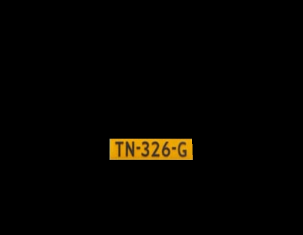

```python
mask1 = np.zeros(gray1.shape,np.uint8)
new_image1 = cv2.drawContours(mask1,[screenCnt1],0,255,-1,)
new_image1 = cv2.bitwise_and(img1,img1,mask=mask1)
cv2_imshow(new_image1)
```

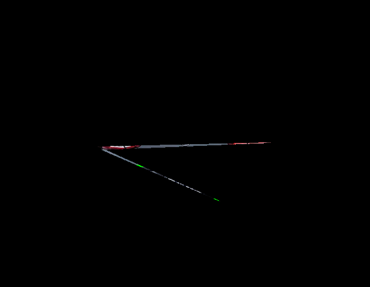

```python
mask2 = np.zeros(gray2.shape,np.uint8)
new_image2 = cv2.drawContours(mask2,[screenCnt2],0,255,-1,)
new_image2 = cv2.bitwise_and(img2,img2,mask=mask2)
cv2_imshow(new_image2)
```

```python
(x1,y1) = np.where(mask1 == 255)
(x2,y2) = np.where(mask2 == 255)
(topx1, topy1) = (np.min(x1), np.min(y1))
(bottomx1, bottomy1) = (np.max(x1), np.max(y1))
(topx2, topy2) = (np.min(x2), np.min(y2))
(bottomx2, bottomy2) = (np.max(x2), np.max(y2))
cropped1 = gray1[topx1:bottomx1+1, topy1:bottomy1+1]
cropped2 = gray2[topx2:bottomx2+1, topy2:bottomy2+1]

cv2_imshow(cropped1)
cv2_imshow(cropped2)
```

[output not shown]

```python
import pytesseract
text1 = pytesseract.image_to_string(cropped1, config='--psm 11')
text2 = pytesseract.image_to_string(cropped2, config='--psm 11')
print(f'Car1 license plate: {text1}')
print(f'Car2 license plate: {text2}')
```

```
Car1 license plate: TN-326-G

Car2 license plate: HP
```

Task 2b: Answer here

Car2 image fails here because the model is unable to detect the 4 points that would make up the license plate window. This is evident by new image 2 above showing a random piece of the car rather than the plate.

# Submission Instructions

1. Perform a Restart and Run All by clicking **Tools > Restart session and run all**.
2. Copy the link to your notebook by clicking **Share > Copy Link**.
3. Paste the copied link into the `notebook_url` field in the [Notebook Renderer](https://colab.research.google.com/drive/1CJTipys46ldZxJFwnt7XbdjQUfkmoXeU?usp=sharing) tool and then execute the cell to render the notebook.
4. The Notebook Renderer will open up a save file dialog. Save the resulting HTML file yo your local machine.
5. Submit the HTML file to Canvas.